## Performing Eigenanalysis of a Large Sparse data Using Machine Learning

# Machine Learning for Eigenanalysis

```python
import pandas as pd
import numpy as np
import seaborn as sns
import matplotlib.pyplot as plt
from sklearn.model_selection import (
    GridSearchCV,
    RandomizedSearchCV,
    cross_val_score,
    cross_validate,
    train_test_split,
    cross_val_predict
)
from sklearn.metrics import (
    accuracy_score,
    classification_report,
    confusion_matrix,
    f1_score,
    make_scorer,
    precision_score,
    recall_score,
    plot_confusion_matrix,
    precision_recall_curve,
    average_precision_score,
    roc_curve,
    roc_auc_score
)

from pandas.plotting import scatter_matrix
from sklearn.compose import ColumnTransformer, make_column_transformer
from sklearn.pipeline import Pipeline, make_pipeline
from sklearn.preprocessing import StandardScaler
from sklearn.dummy import DummyClassifier
from sklearn.linear_model import LogisticRegression
import xgboost as xgb
from lightgbm.sklearn import LGBMClassifier
from sklearn.neighbors import KNeighborsClassifier
from sklearn.svm import SVC
import eli5
import shap

pd.set_option('display.max_columns', 10)
plt.rcParams["font.size"] = 16

import warnings
warnings.filterwarnings(action='ignore', category=UserWarning)
```

Let's start with the problem. Eigenanalysis for large systems requires high computational resources. Reducing the computational time of the solution to a large eigenproblem in many areas of science and engineering has been the subject of numerous studies. Here, I am employing different machine learning models to try to predict the eigenvalues of a given matrix.

The matrix that I start with is a large `502x502` sparse system of linear equations resulting from the Jacobian of the solution to the [Burgers](https://en.wikipedia.org/wiki/Burgers%27_equation) problem. In this project, gathering data is one of the most difficult tasks (if not the most difficult) due to the variety in problems. I have gathered the information for as many matrices as possible to try to emulate a true machine learning pipeline.

To generate many matrices, the numerical mesh used to set up the [Burgers equations](https://en.wikipedia.org/wiki/Burgers%27_equation) on is changed in a certain. For this purpose, `vertex[15]` is moved around and the resulting [Jacobian](https://en.wikipedia.org/wiki/Jacobian_matrix_and_determinant) matrix is used for the [eigenanalysis](https://en.wikipedia.org/wiki/Eigenvalues_and_eigenvectors). The following figure shows the location of `vertex[15]` in relation to the adjacent cells. This figure also depicts the coordinates of the neighboring vertices.

#### The numerical mesh

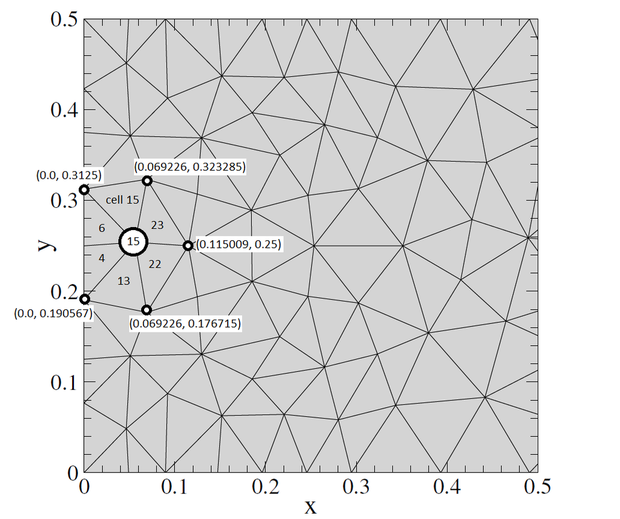

The next issue is that for each entry in the data there will be at least `502x502 = 252004` vector entries which correspond to about `252k` features. Given the number of examples in the data I have gathered, training an ML model would be impossible. As a result, I have used a clever way to extract the most important features to the problem at hand. This selection will differ from problem to problem. For now, I won't go into detail of this method.

## Data Analysis

In this section, I will explain the data and relevant features and the target.

```python
df = pd.read_csv('Burgers-test-1.csv')
df
```

|  | vertex[15] x | vertex[15] y | jac[4][4] | jac[4][6] | jac[4][13] | ... | jac[23][13] | jac[23][15] | jac[23][22] | jac[23][23] | eigenvalue |
| --- | --- | --- | --- | --- | --- | --- | --- | --- | --- | --- | --- |
| 0 | 0.000692 | 0.19104 | -0.83566 | 0.282060 | 0.79353 | ... | 21.89600 | -15.430 | 52.0310 | -69.34400 | -0.28547 |
| 1 | 0.000692 | 0.19164 | -0.83187 | 0.279730 | 0.79228 | ... | 21.77300 | -15.505 | 52.2790 | -69.06300 | -0.28658 |
| 2 | 0.000692 | 0.19711 | -0.79771 | 0.258710 | 0.78106 | ... | 20.66700 | -16.179 | 54.5080 | -66.53000 | -0.29703 |
| 3 | 0.000692 | 0.25182 | -0.45521 | 0.048438 | 0.66865 | ... | 9.60790 | -22.916 | 76.8040 | -41.20300 | -0.47191 |
| 4 | 0.000692 | 0.25243 | -0.45140 | 0.046101 | 0.66740 | ... | 9.48500 | -22.991 | 77.0520 | -40.92200 | -0.47545 |
| ... | ... | ... | ... | ... | ... | ... | ... | ... | ... | ... | ... |
| 38835 | 0.114560 | 0.24997 | 131.76000 | -92.123000 | -56.70800 | ... | -0.15607 | 24.314 | 3.1713 | 0.30762 | 245.82000 |
| 38836 | 0.114560 | 0.24997 | 131.76000 | -92.128000 | -56.71000 | ... | -0.15608 | 24.314 | 3.1713 | 0.30711 | 245.82000 |
| 38837 | 0.114560 | 0.24998 | 131.77000 | -92.133000 | -56.71300 | ... | -0.15608 | 24.315 | 3.1713 | 0.30660 | 245.83000 |
| 38838 | 0.114560 | 0.24999 | 131.78000 | -92.137000 | -56.71500 | ... | -0.15609 | 24.315 | 3.1713 | 0.30608 | 245.84000 |
| 38839 | 0.114560 | 0.25000 | 131.79000 | -92.142000 | -56.71800 | ... | -0.15609 | 24.315 | 3.1713 | 0.30557 | 245.85000 |

38840 rows × 39 columns

```python
df.dtypes
```

```
vertex[15] x    float64
vertex[15] y    float64
jac[4][4]       float64
jac[4][6]       float64
jac[4][13]      float64
jac[4][15]      float64
jac[4][22]      float64
jac[4][23]        int64
jac[6][4]       float64
jac[6][6]       float64
jac[6][13]      float64
jac[6][15]      float64
jac[6][22]        int64
jac[6][23]      float64
jac[13][4]      float64
jac[13][6]      float64
jac[13][13]     float64
jac[13][15]       int64
jac[13][22]     float64
jac[13][23]     float64
jac[15][4]      float64
jac[15][6]      float64
jac[15][13]     float64
jac[15][15]     float64
jac[15][22]     float64
jac[15][23]     float64
jac[22][4]      float64
jac[22][6]        int64
jac[22][13]     float64
jac[22][15]     float64
jac[22][22]     float64
jac[22][23]     float64
jac[23][4]        int64
jac[23][6]      float64
jac[23][13]     float64
jac[23][15]     float64
jac[23][22]     float64
jac[23][23]     float64
eigenvalue      float64
dtype: object
```

The data includes `38` features and a single target value. The features and target are all numeric values. Here is a description of these values;

- `vertex[15] x` shows the x coordinate of the vertex with `id = 15` in the mesh.
- `vertex[15] y` shows the y coordinate of the vertex with `id = 15` in the mesh.
- `jac[i][j]` is the value on row `i` and column `j` in the Jacobian matrix.
- `eigenvalue` is the real part of the right-most eigenvalue of the Jacobian matrix. This is our target value.

There are no missing values.

```python
df_description = df.describe(include = 'all')
df_description
```

|  | vertex[15] x | vertex[15] y | jac[4][4] | jac[4][6] | jac[4][13] | ... | jac[23][13] | jac[23][15] | jac[23][22] | jac[23][23] | eigenvalue |
| --- | --- | --- | --- | --- | --- | --- | --- | --- | --- | --- | --- |
| count | 38840.000000 | 38840.000000 | 38840.000000 | 38840.000000 | 38840.00000 | ... | 38840.000000 | 38840.000000 | 38840.000000 | 38840.000000 | 38840.000000 |
| mean | 0.064300 | 0.250411 | 39.575594 | -35.072945 | -4.20193 | ... | -3.771587 | 3.177027 | 32.971334 | -16.375711 | 71.399543 |
| std | 0.032873 | 0.032130 | 46.230474 | 30.400564 | 22.77777 | ... | 5.792621 | 12.491575 | 22.215507 | 13.966263 | 80.653834 |
| min | 0.000692 | 0.177440 | -26.001000 | -92.601000 | -56.96600 | ... | -14.586000 | -30.325000 | 3.170700 | -69.344000 | -5.512400 |
| 25% | 0.035998 | 0.228470 | -2.094550 | -62.168000 | -20.94300 | ... | -7.318025 | -5.517500 | 14.689500 | -23.231750 | -5.512400 |
| 50% | 0.069453 | 0.250160 | 28.664500 | -30.483500 | 3.76805 | ... | -4.635550 | 2.221500 | 27.358500 | -11.200500 | 46.089500 |
| 75% | 0.092797 | 0.272340 | 79.616250 | -5.369400 | 14.02125 | ... | -1.504650 | 13.530000 | 48.653250 | -6.554850 | 136.812500 |
| max | 0.114560 | 0.322560 | 132.530000 | 6.370400 | 27.18000 | ... | 21.896000 | 24.347000 | 101.330000 | 0.356300 | 246.610000 |

8 rows × 39 columns

Some features are always zero or close to zero. We are safe to remove these features as they won't affect our eventual ML model.

```python
drop_list = []

for column in df.columns:
    diff = np.abs(df_description.loc['max', column] - df_description.loc['min', column])
    if diff < 1e-6:
        drop_list.append(column)

df.drop(columns = drop_list, inplace = True)
```

Here is the list of the dropped features.

```python
drop_list
```

```
['jac[4][15]',
 'jac[4][23]',
 'jac[6][22]',
 'jac[6][23]',
 'jac[13][6]',
 'jac[13][15]',
 'jac[22][6]',
 'jac[22][15]',
 'jac[23][4]']
```

As the first experiment, I will only focus on finding out whether the `eigenvalue` target is positive or negative. As a result, I am going to change the problem into a classification problem by changing the target value to binary. I am removing `eigenvalue` column and adding `target` column.

```python
df['target'] = (df['eigenvalue'] > 0).astype(int)
df.drop(columns = ['eigenvalue'], inplace = True)
```

```python
df
```

|  | vertex[15] x | vertex[15] y | jac[4][4] | jac[4][6] | jac[4][13] | ... | jac[23][13] | jac[23][15] | jac[23][22] | jac[23][23] | target |
| --- | --- | --- | --- | --- | --- | --- | --- | --- | --- | --- | --- |
| 0 | 0.000692 | 0.19104 | -0.83566 | 0.282060 | 0.79353 | ... | 21.89600 | -15.430 | 52.0310 | -69.34400 | 0 |
| 1 | 0.000692 | 0.19164 | -0.83187 | 0.279730 | 0.79228 | ... | 21.77300 | -15.505 | 52.2790 | -69.06300 | 0 |
| 2 | 0.000692 | 0.19711 | -0.79771 | 0.258710 | 0.78106 | ... | 20.66700 | -16.179 | 54.5080 | -66.53000 | 0 |
| 3 | 0.000692 | 0.25182 | -0.45521 | 0.048438 | 0.66865 | ... | 9.60790 | -22.916 | 76.8040 | -41.20300 | 0 |
| 4 | 0.000692 | 0.25243 | -0.45140 | 0.046101 | 0.66740 | ... | 9.48500 | -22.991 | 77.0520 | -40.92200 | 0 |
| ... | ... | ... | ... | ... | ... | ... | ... | ... | ... | ... | ... |
| 38835 | 0.114560 | 0.24997 | 131.76000 | -92.123000 | -56.70800 | ... | -0.15607 | 24.314 | 3.1713 | 0.30762 | 1 |
| 38836 | 0.114560 | 0.24997 | 131.76000 | -92.128000 | -56.71000 | ... | -0.15608 | 24.314 | 3.1713 | 0.30711 | 1 |
| 38837 | 0.114560 | 0.24998 | 131.77000 | -92.133000 | -56.71300 | ... | -0.15608 | 24.315 | 3.1713 | 0.30660 | 1 |
| 38838 | 0.114560 | 0.24999 | 131.78000 | -92.137000 | -56.71500 | ... | -0.15609 | 24.315 | 3.1713 | 0.30608 | 1 |
| 38839 | 0.114560 | 0.25000 | 131.79000 | -92.142000 | -56.71800 | ... | -0.15609 | 24.315 | 3.1713 | 0.30557 | 1 |

38840 rows × 30 columns

Let's focus on the data and do some experiments with it to familiarize ourselves.

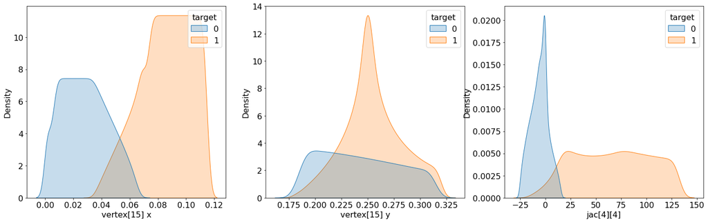

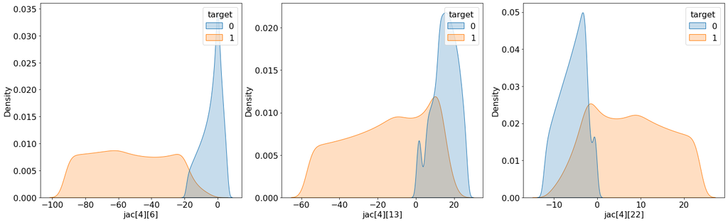

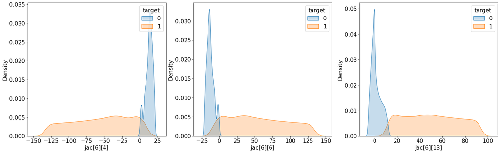

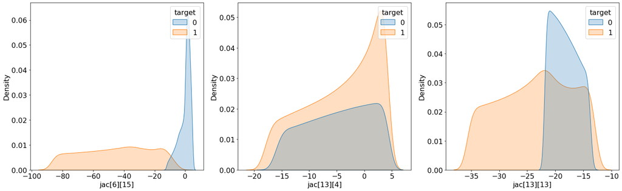

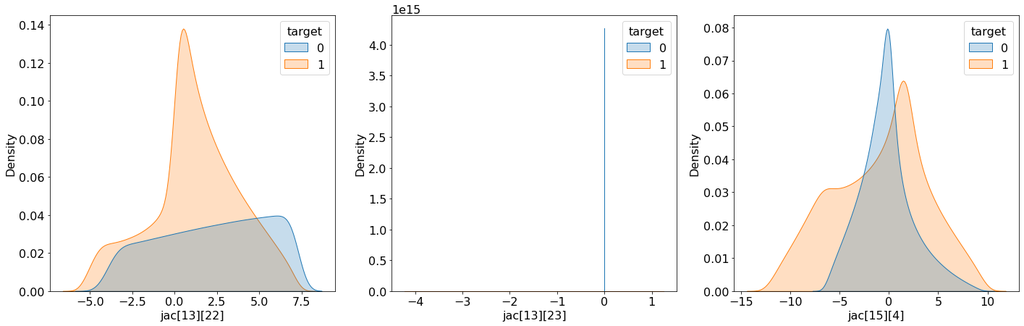

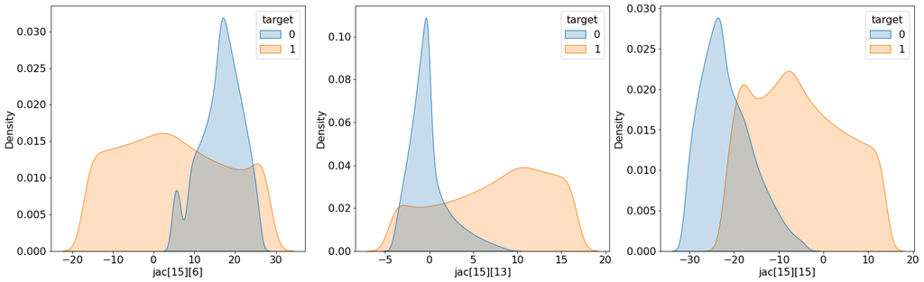

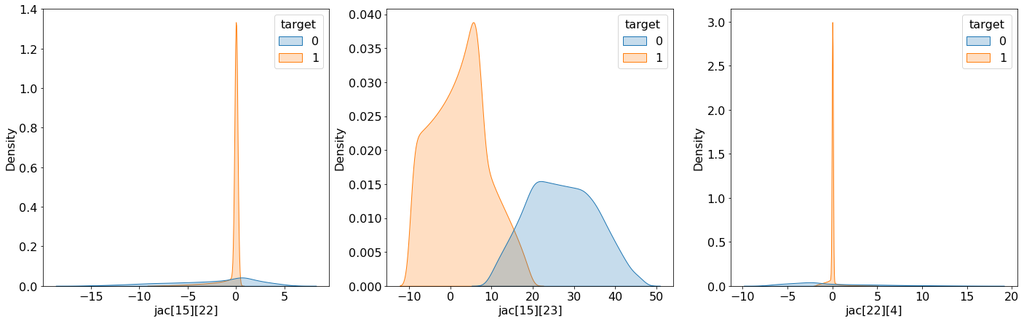

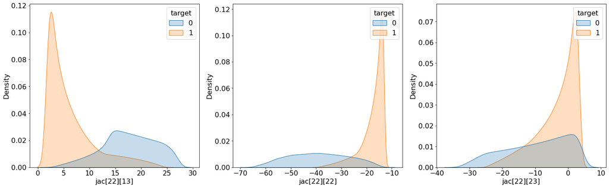

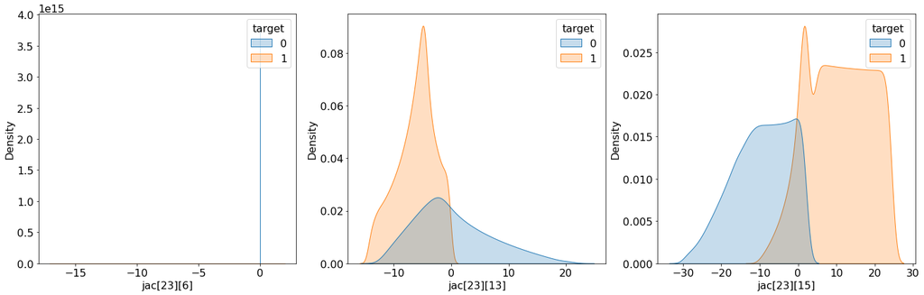

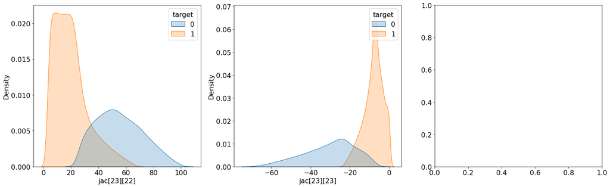

```python
features = df.columns
features = features.drop('target')
for feature in features:
    k = features.get_loc(feature) % 3
    if k == 0:
        fig, axes = plt.subplots(1, 3, figsize = (24, 7))
    sns.kdeplot(df[feature], shade = True, hue = df['target'], ax = axes[k])
```

As seen, there is good separation between target values for most features. As a result, tree-based models might work well for our application.

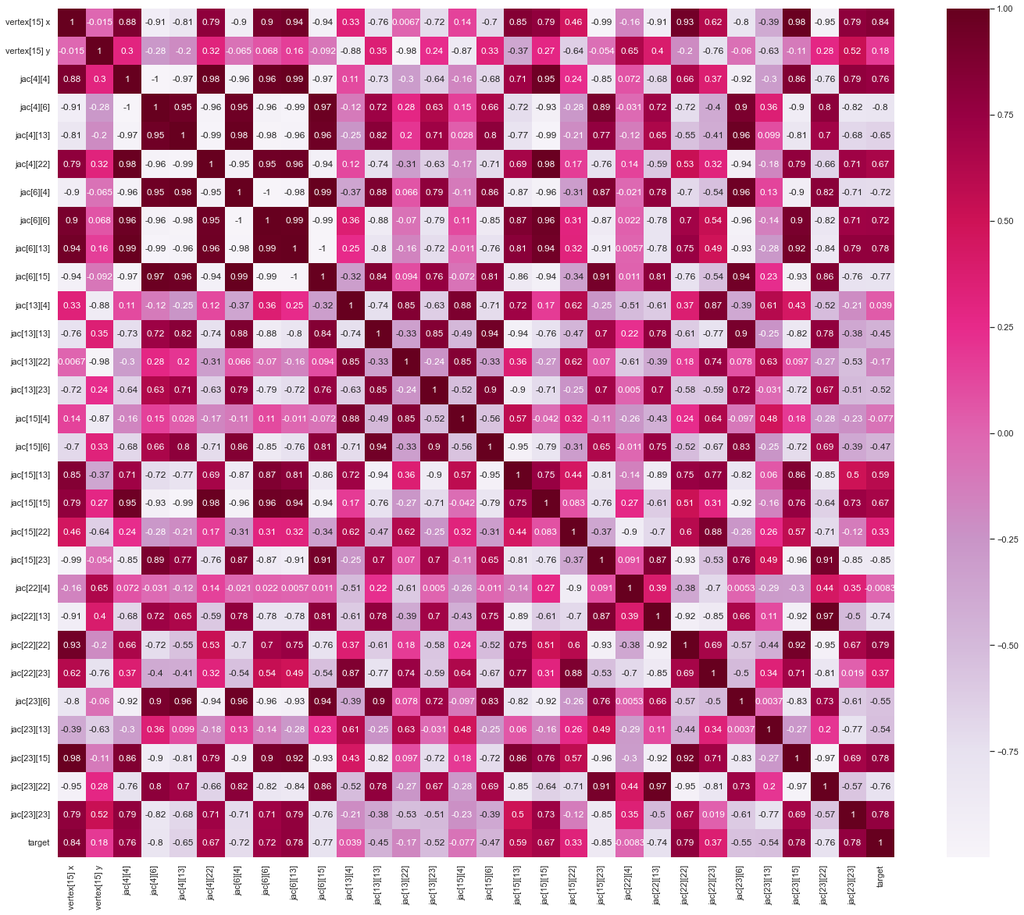

```python
cor = df.corr()
plt.figure(figsize = (24, 20))
sns.set()
sns.heatmap(cor, annot = True, cmap = plt.cm.PuRd);
```

As seen, there is good linear correlation between `target` and many features.

## Problem Definition

Let's first have a look at a contour plot that explains the relation between two features `vertex[15] x` and `vertex[15] y` and the original target value (the real part of the least stable eigenvalue). As seen here, there is a clear boundary between the eigenvalues with positive and negative real parts. It seems we are able to use tree-based models for the classification problem at hand. We can also use `KNNs` and `SVM RBF`.

#### Contour plot of eigenvalue vs mesh coordinates

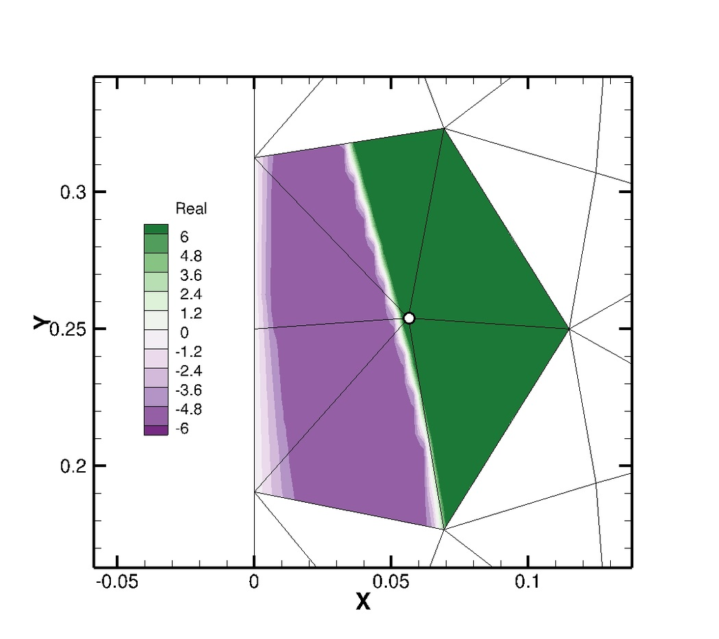

As a result, let's only use the first two features `vertex[15] x` and `vertex[15] y` to predict the binary target.

```python
numeric_features = ['vertex[15] x', 'vertex[15] y']
```

## Data Splitting and Target Extraction

Next, I will split the data into `train` and `test` splits. I use 20% of the examples for the `test` portion which is an acceptable size as we have many examples in our data.

```python
df_train, df_test = train_test_split(df, test_size = 0.2, random_state = 0)

print(f"There are {df_train.size:g} training and {df_test.size:g} test examples.")

pos_neg_ratio = df[df['target']==1].size/df[df['target']==0].size
print(f"The ratio of positive examples to negative examples is {pos_neg_ratio:f}")
```

```
There are 932160 training and 233040 test examples.
The ratio of positive examples to negative examples is 1.696660
```

```python
X_train = df_train[numeric_features]
y_train = df_train['target']
X_test = df_test[numeric_features]
y_test = df_test['target']
```

Define a preprocessor to apply scalar transformation to the `numeric_features`.

```python
preprocessor = make_column_transformer(
    (
        StandardScaler(), numeric_features
    )
)
preprocessor
```

```
ColumnTransformer(transformers=[('standardscaler', StandardScaler(),
                                 ['vertex[15] x', 'vertex[15] y'])])
```

Define a pipeline for the application of the preprocessor along with a `DummyClassifier`.

```python
pipeline = make_pipeline(preprocessor, DummyClassifier(strategy = 'prior'))
pipeline
```

```
Pipeline(steps=[('columntransformer',
                 ColumnTransformer(transformers=[('standardscaler',
                                                  StandardScaler(),
                                                  ['vertex[15] x',
                                                   'vertex[15] y'])])),
                ('dummyclassifier', DummyClassifier())])
```

I am defining the following function for cross-validation purposes.

```python
def mean_std_cross_val_scores(model, X_train, y_train, **kwargs):
    score = cross_validate(model, X_train, y_train, **kwargs)

    mean = pd.DataFrame(score).mean()
    std = pd.DataFrame(score).std()

    return {'value': mean, 'std': std}

results_dict = {}  # dictionary to store all the results
```

I am using scoring method of `roc_auc` which is a good choice for classification problems with class imbalance.

```python
results_dict['dummy'] = mean_std_cross_val_scores(pipeline, X_train, y_train, cv = 5, return_train_score = True, scoring = 'roc_auc', n_jobs = -1)
pd.DataFrame(results_dict['dummy'])
```

|  | value | std |
| --- | --- | --- |
| fit_time | 0.024997 | 0.008560 |
| score_time | 0.003126 | 0.006989 |
| test_score | 0.500000 | 0.000000 |
| train_score | 0.500000 | 0.000000 |

The Area Under Curve (auc) score is equal to 0.5 which is the result of random guessing. This is the expected behavior from a `DummyClassifier`.

Next, let's try a `LogisticRegression` model. Here, I am carrying out hyperparameter optimization using `RandomizedSearchCV`. The optimization is performed for the hyperparameter `C` in `LogisticRegression`.

```python
C_Vals = np.logspace(-2.0, 3.0, num = 41)
params = {'logisticregression__C': C_Vals}

pipeline = make_pipeline(preprocessor, LogisticRegression(max_iter = 2000, class_weight = 'balanced'))

rscv = RandomizedSearchCV(pipeline, params, n_iter = 20, n_jobs = -1, random_state = 0, scoring = "roc_auc")
rscv.fit(X_train, y_train)

print(rscv.best_params_['logisticregression__C'])
```

```
237.13737056616552
```

I am making a new pipeline with the optimized hyperparameter value for `C` in `LogisticRegression`.

```python
pipeline = make_pipeline(preprocessor, LogisticRegression(max_iter = 2000, C = rscv.best_params_['logisticregression__C'], class_weight = 'balanced'))

results_dict['logisticregression'] = mean_std_cross_val_scores(pipeline, X_train, y_train, cv = 10, return_train_score = True, scoring = 'roc_auc', n_jobs = -1)
pd.DataFrame(results_dict['logisticregression'])
```

|  | value | std |
| --- | --- | --- |
| fit_time | 0.122251 | 0.020347 |
| score_time | 0.010991 | 0.006978 |
| test_score | 0.999884 | 0.000031 |
| train_score | 0.999883 | 0.000004 |

```python
models = {
    'knn': KNeighborsClassifier(),
    'svm': SVC(class_weight = 'balanced'),
    'xgboost': xgb.XGBClassifier(verbosity = 0, use_label_encoder = False, scale_pos_weight = pos_neg_ratio),
}

for model in models:
    pipeline = make_pipeline(preprocessor, models[model])
    results_dict[model] = mean_std_cross_val_scores(pipeline, X_train, y_train, return_train_score = True, n_jobs = -1, scoring = "roc_auc")
```

```python
# The results for KNN
pd.DataFrame(results_dict['knn'])
```

|  | value | std |
| --- | --- | --- |
| fit_time | 0.031774 | 5.338326e-03 |
| score_time | 0.046175 | 9.222107e-03 |
| test_score | 0.999981 | 4.932859e-06 |
| train_score | 0.999996 | 6.668202e-07 |

```python
# The results for SVM
pd.DataFrame(results_dict['svm'])
```

|  | value | std |
| --- | --- | --- |
| fit_time | 2.815376 | 1.019642e-01 |
| score_time | 1.518816 | 1.128823e-01 |
| test_score | 0.999998 | 2.232547e-06 |
| train_score | 0.999998 | 9.477086e-07 |

```python
# The results for XGBoost
pd.DataFrame(results_dict['xgboost'])
```

|  | value | std |
| --- | --- | --- |
| fit_time | 1.873170 | 3.111781e-02 |
| score_time | 0.038276 | 1.691550e-02 |
| test_score | 0.999973 | 1.389701e-05 |
| train_score | 1.000000 | 7.850462e-17 |

All of the new models also perform very well with the default hyperparameter values.

I am choosing the `LogisticRegression` model with the optimized hyperparameter `C` for final evaluation.

```python
pipeline = make_pipeline(preprocessor, LogisticRegression(max_iter = 2000, C = rscv.best_params_['logisticregression__C'], class_weight = 'balanced'))
pipeline.fit(X_train, y_train)

print(classification_report(y_test, pipeline.predict(X_test), target_names = ['negative', 'positive']))
```

```
              precision    recall  f1-score   support

    negative       0.99      0.99      0.99      2871
    positive       1.00      0.99      1.00      4897

    accuracy                           0.99      7768
   macro avg       0.99      0.99      0.99      7768
weighted avg       0.99      0.99      0.99      7768
```

The scores look promising.

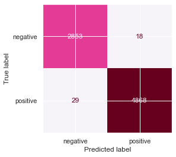

```python
disp = plot_confusion_matrix(
    pipeline,
    X_test,
    y_test,
    display_labels = ['negative', 'positive'],
    values_format = 'g',
    cmap = plt.cm.PuRd,
    colorbar = False,
);
```

## Defining a New Problem

In this section, I will change the problem to use the Jacobian matrix entries as features and will drop the `vertex[15]` location features.

```python
numeric_features = df.columns
numeric_features = numeric_features.drop( ['vertex[15] x', 'vertex[15] y', 'target']).tolist()
numeric_features
```

```
['jac[4][4]',
 'jac[4][6]',
 'jac[4][13]',
 'jac[4][22]',
 'jac[6][4]',
 'jac[6][6]',
 'jac[6][13]',
 'jac[6][15]',
 'jac[13][4]',
 'jac[13][13]',
 'jac[13][22]',
 'jac[13][23]',
 'jac[15][4]',
 'jac[15][6]',
 'jac[15][13]',
 'jac[15][15]',
 'jac[15][22]',
 'jac[15][23]',
 'jac[22][4]',
 'jac[22][13]',
 'jac[22][22]',
 'jac[22][23]',
 'jac[23][6]',
 'jac[23][13]',
 'jac[23][15]',
 'jac[23][22]',
 'jac[23][23]']
```

Define a new column transformer to apply scaling to the new features.

```python
preprocessor = make_column_transformer(
    (
        StandardScaler(), numeric_features
    )
)
preprocessor
```

```
ColumnTransformer(transformers=[('standardscaler', StandardScaler(),
                                 ['jac[4][4]', 'jac[4][6]', 'jac[4][13]',
                                  'jac[4][22]', 'jac[6][4]', 'jac[6][6]',
                                  'jac[6][13]', 'jac[6][15]', 'jac[13][4]',
                                  'jac[13][13]', 'jac[13][22]', 'jac[13][23]',
                                  'jac[15][4]', 'jac[15][6]', 'jac[15][13]',
                                  'jac[15][15]', 'jac[15][22]', 'jac[15][23]',
                                  'jac[22][4]', 'jac[22][13]', 'jac[22][22]',
                                  'jac[22][23]', 'jac[23][6]', 'jac[23][13]',
                                  'jac[23][15]', 'jac[23][22]',
                                  'jac[23][23]'])])
```

```python
X_train = df_train[numeric_features]
y_train = df_train['target']
X_test = df_test[numeric_features]
y_test = df_test['target']
```

```python
results_dict = {}  # dictionary to store all the results
```

For this part, I will use `LGBMClassifier` classifier. Let's build a pipeline and carry out the required computations.

```python
pipeline = make_pipeline(preprocessor, LGBMClassifier(random_state = 0))

results_dict['logisticregression'] = mean_std_cross_val_scores(pipeline, X_train, y_train, cv = 10, return_train_score = True, scoring = 'roc_auc', n_jobs = -1)
pd.DataFrame(results_dict['logisticregression'])
```

|  | value | std |
| --- | --- | --- |
| fit_time | 2.015266 | 5.095330e-01 |
| score_time | 0.046659 | 3.486688e-02 |
| test_score | 0.999997 | 3.152882e-06 |
| train_score | 1.000000 | 5.233642e-17 |

Same as before, we are getting astonishing results.

```python
pipeline.fit(X_train, y_train)

print(classification_report(y_test, pipeline.predict(X_test), target_names = ['negative', 'positive']))
```

```
              precision    recall  f1-score   support

    negative       1.00      1.00      1.00      2871
    positive       1.00      1.00      1.00      4897

    accuracy                           1.00      7768
   macro avg       1.00      1.00      1.00      7768
weighted avg       1.00      1.00      1.00      7768
```

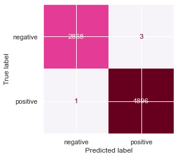

```python
disp = plot_confusion_matrix(
    pipeline,
    X_test,
    y_test,
    display_labels = ['negative', 'positive'],
    values_format = 'g',
    cmap = plt.cm.PuRd,
    colorbar = False,
);
```

## Study Feature Importance

An important task that is left is to study feature importance and figure out which features are contributing most to our predictions. For `LogisticRegression` we can simply look into the feature coefficients. However, in the case of non scikit-learn models such as `LGBMClassifier` we need to use more sophisticated methods. Let's start with [eli5](https://eli5.readthedocs.io/en/latest/index.html). We can use [eli5](https://eli5.readthedocs.io/en/latest/index.html) to explain the weights with features in our `LGBMClassifier` model.

```python
eli5.explain_weights(pipeline.named_steps['lgbmclassifier'], feature_names = numeric_features)
```

| Weight | Feature |
| --- | --- |
| 0.9596 | jac[6][13] |
| 0.0151 | jac[4][6] |
| 0.0100 | jac[15][15] |
| 0.0082 | jac[6][15] |
| 0.0023 | jac[6][6] |
| 0.0021 | jac[6][4] |
| 0.0014 | jac[4][4] |
| 0.0003 | jac[22][4] |
| 0.0002 | jac[15][6] |
| 0.0002 | jac[4][13] |
| 0.0001 | jac[4][22] |
| 0.0001 | jac[13][4] |
| 0.0001 | jac[15][23] |
| 0.0001 | jac[23][23] |
| 0.0001 | jac[15][22] |
| 0.0000 | jac[13][13] |
| 0.0000 | jac[15][4] |
| 0.0000 | jac[22][13] |
| 0.0000 | jac[23][13] |
| 0.0000 | jac[15][13] |
| *… 7 more …* |  |

Here, [eli5](https://eli5.readthedocs.io/en/latest/index.html) tells us that the feature with the highest impact on prediction is `jac[6][13]` which is interesting.

```python
shap_explainer = shap.TreeExplainer(pipeline.named_steps['lgbmclassifier'])
shap_explainer_values = shap_explainer.shap_values(X_train)
```

LightGBM binary classifier with TreeExplainer shap values output has changed to a list of ndarray.

```python
shap_explainer_values[1].shape
```

```
(31072, 27)
```

```python
shap_explainer_values_test = shap_explainer.shap_values(X_test)
shap_explainer_values_test[1].shape
```

```
(7768, 27)
```

```python
values = np.abs(shap_explainer_values_test[1]).mean(0)
pd.DataFrame(data = values, index = numeric_features, columns = ['SHAP values']).sort_values(by = 'SHAP values', ascending = False)
```

|  | SHAP values |
| --- | --- |
| jac[6][13] | 4.545563e+00 |
| jac[15][15] | 3.949945e+00 |
| jac[6][15] | 1.396141e+00 |
| jac[4][6] | 1.038393e+00 |
| jac[22][4] | 5.268402e-01 |
| jac[6][4] | 4.235165e-01 |
| jac[15][6] | 3.677990e-01 |
| jac[4][4] | 2.213640e-01 |
| jac[6][6] | 1.527950e-01 |
| jac[15][4] | 2.970371e-02 |
| jac[23][23] | 2.081470e-02 |
| jac[4][22] | 1.711044e-02 |
| jac[13][4] | 1.701067e-02 |
| jac[15][23] | 1.579014e-02 |
| jac[4][13] | 1.380722e-02 |
| jac[23][13] | 1.188273e-02 |
| jac[15][13] | 5.507729e-03 |
| jac[13][13] | 4.731218e-03 |
| jac[13][22] | 2.703677e-03 |
| jac[15][22] | 2.531152e-03 |
| jac[23][15] | 8.954353e-04 |
| jac[22][22] | 7.199953e-04 |
| jac[22][13] | 7.131488e-04 |
| jac[22][23] | 4.571032e-04 |
| jac[23][22] | 1.535875e-04 |
| jac[13][23] | 1.050718e-18 |
| jac[23][6] | 0.000000e+00 |

[SHAP](https://shap.readthedocs.io/en/latest/index.html) is also telling us that the most important feature to predict the positive class on average is `jac[6][13]`. Here, `jac[15][15]` also has a large importance. We can think of these values as global feature importance.

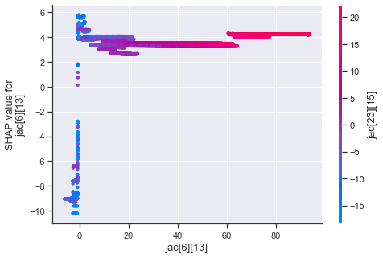

```python
shap.initjs()
shap.dependence_plot('jac[6][13]', shap_explainer_values[1], X_train)
```

This dependence plot tells us that for high values of `jac[6][13]` we are likely to get high `SHAP` values which correspond to predicting the positive class. On the other hand, lower values of `jac[6][13]` gives us lower `SHAP` values to predict the negative class.

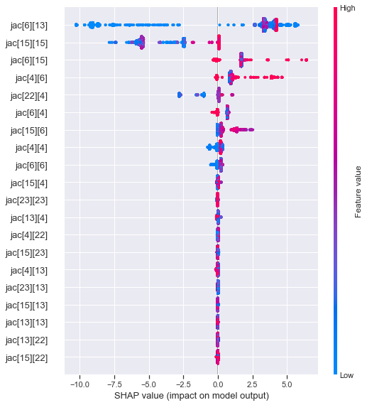

```python
shap.summary_plot(shap_explainer_values[1], X_train)
```

The summary plot also tells us that higher values of `jac[6][13]` are likely to give the positive class which is the same for `jac[15][15]`.

Now, let's try to explain the prediction for some of the examples. Here is the prediction probability for one example.

```python
ex1_id = 0
pipeline.named_steps["lgbmclassifier"].predict_proba(X_test)[ex1_id]
```

```
array([0.29239654, 0.70760346])
```

And here is the raw score of the model for this prediction.

```python
pipeline.named_steps["lgbmclassifier"].predict(X_test, raw_score = True)[ex1_id]
```

```
0.8837729529463807
```

```python
shap_explainer.expected_value[1]
```

```
3.022102865429598
```

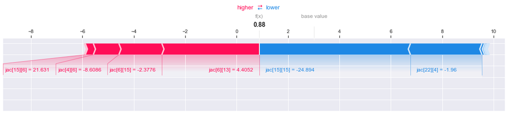

```python
shap.force_plot(
    shap_explainer.expected_value[1],
    shap_explainer_values_test[1][ex1_id, :],
    X_test.iloc[ex1_id, :],
    matplotlib = True,
)
```

```python
y_test.iloc[ex1_id]
```

```
0
```

Next example,

```python
ex2_id = 1000
pipeline.named_steps["lgbmclassifier"].predict_proba(X_test)[ex2_id]
```

```
array([1.6439865e-05, 9.9998356e-01])
```

```python
pipeline.named_steps["lgbmclassifier"].predict(X_test, raw_score = True)[ex2_id]
```

```
11.015784937396734
```

```python
shap_explainer.expected_value[1]
```

```
3.022102865429598
```

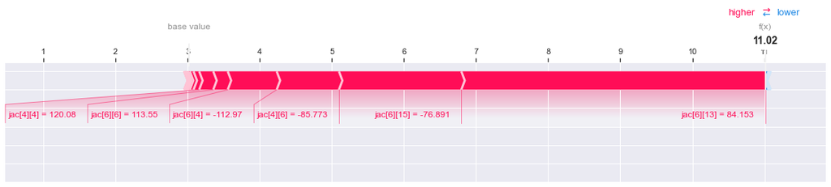

```python
shap.force_plot(
    shap_explainer.expected_value[1],
    shap_explainer_values_test[1][ex2_id, :],
    X_test.iloc[ex2_id, :],
    matplotlib = True,
)
```

Here, the raw score is higher than the base value which means we are predicting the positive class. This is a correct prediction as presented in the following.

```python
y_test.iloc[ex2_id]
```

```
1
```